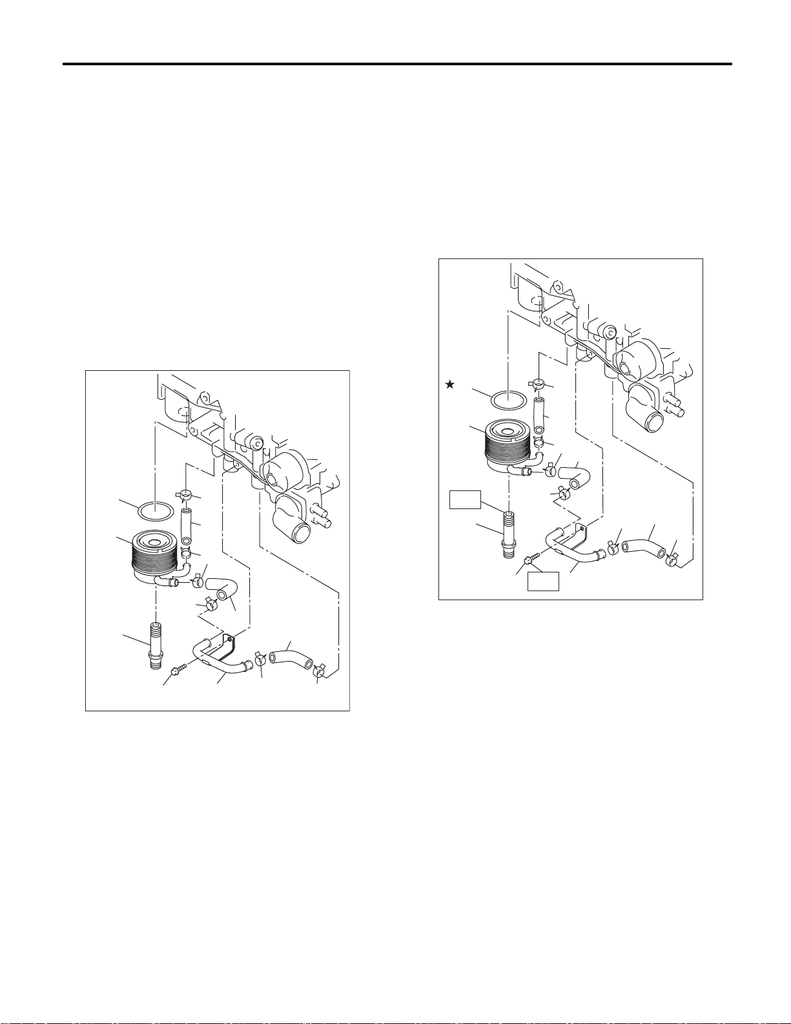

LU(STI)-23

Engine Oil Cooler

LUBRICATION

7. Engine Oil Cooler

A: REMOVAL

CAUTION:

If engine oil is spilt onto the exhaust pipe, wipe

it off with cloth to avoid emission of smoke or

causing a fire.

1) Drain engine coolant. <Ref. to CO(STI)-13,

DRAINING OF ENGINE COOLANT, REPLACE-

MENT, Engine Coolant.>

2) Remove the engine oil filter. <Ref. to LU(STI)-

29, REMOVAL, Engine Oil Filter.>

3) Remove the bolt (B) holding the oil cooler pipe

(A) to the oil pump.

4) Remove the oil cooler pipe (A), oil cooler hose A

(C), oil cooler hose B (H), and oil cooler hose C (I).

5) Remove the oil cooler connector (D) and oil cool-

er (E).

B: INSTALLATION

Install in the reverse order of removal.

NOTE:

• Use a new gasket.

• After installing, check the engine oil level and re-

plenish it if necessary. <Ref. to LU(STI)-11, IN-

SPECTION, Engine Oil.>

Tightening torque:

T1: 6.4 N·m (0.7 kgf-m, 4.7 ft-lb)

T2: 54 N·m (5.5 kgf-m, 39.8 ft-lb)

C: INSPECTION

1) Check that the engine oil cooler, oil cooler pipe

and oil cooler connector do not have deformation,

cracks or damage.

2) Make sure the oil cooler hoses are not cracked,

damaged or loose.

3) Blow with compressed air to make sure the cool-

ant passages are not clogged.

4) Make sure the mating surfaces of the cylinder

block do not have damage.

(A) Oil cooler pipe

(B) Bolt

(C) Oil cooler hose A

(D) Oil cooler connector

(E) Oil cooler

(F) Gasket

(G) Clip

(H) Oil cooler hose B

(I) Oil cooler hose C

LU-02837

(A) Oil cooler pipe

(B) Bolt

(C) Oil cooler hose A

(D) Oil cooler connector

(E) Oil cooler

(F) Gasket

(G) Clip

(H) Oil cooler hose B

(I) Oil cooler hose C

LU-02838